# Connectivity

Author

Affiliation

Vegar Bakkestuen

Norwegian Institute for Nature Research

Published

August 29, 2024

**Status**

This indicator documentation is incomplete and needs further developement before indicator values can be calculated.

**Recomended citation**

Vegar Bakkestuen 2023 Connectivity v. 0.002 ecRxiv https://github.com/NINAnor/ecRxiv/tree/main/indicators/NO_CONN, Vegar Bakkestuen 2023 Connectivity v. 0.002 ecRxiv https://github.com/NINAnor/ecRxiv/tree/main/indicators/NO_CONN

**Version**

0.002

**Show metadata**

Table 1: Indicator metadata

| Indicator ID | NO_CONN_001 |
| --- | --- |
| Indicator Name | Connectivity |
| Country | Norway |
| Continent | NA |
| Ecosystem Condition Typology Class | C1 |
| Year added | 2023 |
| Last update | 2023 |
| Variable | Value |
| Indicator ID | NO_CONN_001 |
| Indicator Name | Connectivity |
| Country | Norway |
| Continent | Europe |
| Ecosystem Condition Typology Class | C1 |
| Realm | Terrestrial |
| Biome | TF1 Palustrine wetlands biome |
| Ecosystem | NA |
| Year added | 2023 |
| Last update | 2024 |
| status | incomplete |
| Version | 0.002 |
| Version comment | Working pipeline, but not oerationalised. Compared to v.0.001 this version is updated with new headers, and some other formatting issues. |
| url | https://github.com/NINAnor/ecRxiv/tree/main/indicators/NO_CONN |

## 1. Introduction

Loss of natural habitat and changes in landscape patterns are central issues in biogeography and conservation biology. The loss of connectivity (connections or linkages) between suitable habitats affects individuals, populations, and communities through various ecosystem interactions. In landscape ecology, connectivity is essentially defined as “the degree to which the landscape facilitates or impedes movement between patches of resources or suitable habitats.” The concept of connectivity encompasses both structural connectivity, which involves the physical locations of suitable and unsuitable habitats or patches being analyzed, and functional connectivity, which focuses on the actual movement of individuals across suitable and unsuitable habitats and disturbance barriers. We have assessed that there is currently insufficient data available to start calculating functional connectivity on a national scale in relation to the assessment of ecological condition, as there is almost a total lack of relevant data for almost all species. Therefore, we have developed an index for structural connectivity based on physical interventions calculated using an infrastructure index (Erikstad et al. 2023) and a new wetland map for Norway (Bakkestuen et al. 2023, Bakkestuen et al. in prep).

It is also possible to create a time series for this indicator, but this is not yet done. See [GitHub issue](https://github.com/NINAnor/ecosystemCondition/issues/145).

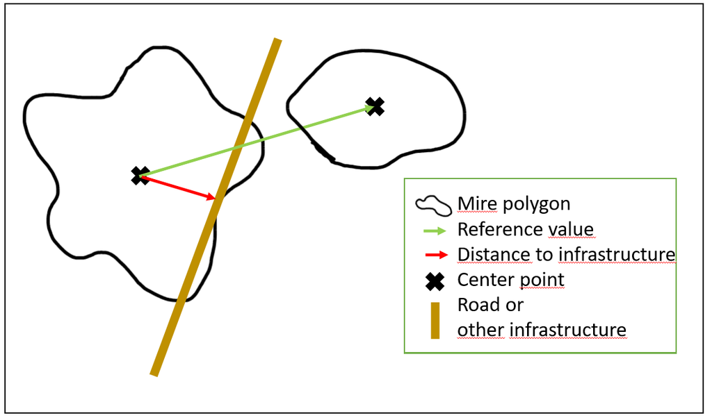

## 2. About the underlying data

The **infrastructure index** is one part of the connectivity index for wetlands. The infrastructure index was calculated for three time points: 2003, 2013, and 2023. This provides a temporal perspective for assessing changes over time. The data used included information on various types of infrastructure, such as roads and buildings. Additionally, a **new wetland** map for Norway has been developed. This map is based on Sentinel-2 and LiDAR data from the year 2020. The U-Net model, implemented through Google Earth Engine and TensorFlow, has been used for mapping wetlands in southern Norway. The model achieved a balanced accuracy rate of 90.9% when validated against ground-truth samples, significantly improving upon the accuracy rates achieved with manually digitized maps in Norway.

### 2.1 Spatial and temporal resolution

The data for the infrastructure index covers the entire country and was collected for three time points over a 20-year period. This provides a broad and representative dataset for assessing changes in connectivity in Norwegian landscapes. The wetland mapping was conducted using data from the year 2020, making it representative for that specific time frame. However, the model used in the mapping process can be applied to other time frames if necessary.

The data covers three time points: 2003, 2013, and 2023. This provides a 20-year temporal perspective for assessing changes in connectivity over time. The wetland mapping provides information in the form of pixel values representing wetland presence or absence.

### 2.2. Original units

The infrastructure index has no specific units as it is a measure of landscape fragmentation and disruption. It is expressed as a dimensionless index.

### 2.3. Aditional comments about the dataset

It is important to note that infrastructure data are based on available map and geographical data sources. Sometimes, there may be variations and uncertainties in this data that can affect the accuracy of the infrastructure index.

## 3. Indicator properties

### 3.1. ECT

In the framework of the United Nations System of Environmental-Economic Accounting (SEEA EA), the *Connectivity* indicator can be classified as a **C1 Landscape and seascape characteristics** indicator.

### 3.2. Ecosystem condition characteristic

*no information*

### 3.3. Other standards

In the context of the Norwegian standard, the “Connectivity” indicator aligns with the ecosystem characteristic known as **Landskapsøkologiske mønstre**.

### 3.4. Collinearities with other indicators

Connectivity is not thought to exhibit collinearity with any other indicator at the present.

## 4. Reference condition and values

### 4.1. Reference condition

The reference condition for the “Connectivity” indicator is characterized as one with minimal negative human impact on the connectivity of ecosystems. In this reference condition, the landscape exhibits natural and undisturbed patterns of connectivity between suitable habitats. This state represents the optimal ecological condition for connectivity assessment.

### 4.2. Reference values

The reference values for the “Connectivity” indicator are determined by calculating the connectivity or mean distance to mire polygons, when excluding infrastructure from the analysis.

In the report «Vurdering av økologisk tilstand for fjell i Norge i 2021» (Framstad et al. 2021) the value of 0,6 was used as the threshold for good ecological condition. We will tentatively use this threshold value again here. A perpetual discussion about the reference (and threshold values) for the connectivity indicator is maintained on [GitHub.](https://github.com/NINAnor/ecosystemCondition/issues/143)

## 5. Uncertainties

Our wetland mapping model is a powerful tool for large-scale mapping but does come with certain uncertainties. While our U-Net model achieved an impressive balanced accuracy rate of 90.9% when validated against an independent ground-truth sample, it’s essential to recognize that some level of uncertainty is inherent. The model’s accuracy may vary across different wetland types and landscape conditions. The model’s performance might vary in regions with distinct wetland characteristics that differ from our training data. It may not fully capture variations in wetland types or subtle differences in wetland boundaries. The accuracy of the wetland mapping model is influenced by the quality and representativeness of the training data. We made significant efforts to ensure the highest quality, but the inherent variability in ground-truth data may introduce some level of uncertainty.

The infrastructure data sources used for this analysis might contain inaccuracies, errors, or omissions. These can arise from factors like inconsistent reporting and data collection methods. While infrastructure data is a valuable proxy for landscape barriers, it may not capture all potential barriers accurately. For instance, small-scale features or unreported structures could introduce uncertainties in connectivity assessments. The resolution of the infrastructure data might not capture all relevant features at a fine scale. This can affect the precision of connectivity assessments in areas with small, localized infrastructure.

## 6. References

Bakkestuen, V.; Venter, Z.; Ganerød, A.J.; Framstad, E. Delineation of Wetland Areas in South Norway from Sentinel-2 Imagery and LiDAR Using TensorFlow, U-Net, and Google Earth Engine. Remote Sens. 2023, 15, 1203. https://doi.org/10.3390/rs15051203

Bakkestuen, V. et al. in prep. Comprehensive Mapping of Wetland Areas in Norway: An Integration of Sentinel-2 Imagery, LiDAR, and Deep Learning Using TensorFlow and Google Earth Engine

Erikstad, L.; Simensen, T.; Bakkestuen, V.; Halvorsen, R. Index Measuring Land Use Intensity—A Gradient-Based Approach. Geomatics 2023, 3, 188-204. https://doi.org/10.3390/geomatics3010010

Framstad, E., Eide, N.E., Eide, W., Klanderud, K., Kolstad, A., Töpper, J. & Vandvik, V. 2022. Vurdering av økologisk tilstand for fjell i Norge i 2021. NINA Rapport 2050. Norsk institutt for naturforskning.

### 7. Data sets

Two main data sets were included.

A. The infrastructure index (Erikstad et al. 2023) and;

B. The wetland model (Bakkestuen et al. 2023, Bakkestuen et al. *In prep.*)

#### 7.1. Data set A - Infrastructure index

The infrastructure index utilized in this analysis was derived from data sources available through Google Earth Engine (GEE). The index quantifies the presence and distribution of key infrastructure elements such as roads, buildings, and related human-made structures across Norway. The data were available for the years 2003, 2013, and 2023, facilitating an assessment of how infrastructure has evolved in terms of both magnitude and distribution over time. It is important to note that this data forms a fundamental component in the calculation of the connectivity indicator.

#### 7.2. Data set B - Wetland model

The wetland model used in this study was developed based on the integration of Sentinel-2 satellite imagery and LiDAR data, utilizing deep learning techniques. The model provides high-resolution information regarding the distribution and extent of wetland areas within southern Norway, specifically for the year 2020. By fusing spectral and elevation data, this model offers significant improvements over conventional, manually-digitized land cover maps. The wetland model is a critical component of the connectivity analysis, as it aids in the identification of ecologically relevant areas. The data set B for South-Norway is already accessible [here](https://kartkatalog.geonorge.no/metadata/aapen-vtmark-i-soer-norge-basert-p-natur-i-norge-nin-typologi/6b5a34f9-c23d-4cca-a51b-01251c217cb1).

## 8. Analyses

### Uncertainty

The current state of the indicator is as a geospatial data set with one scaled indicator value per mire polygon, and no errors around this value. Future improvement must include aggregating these indicator values to regions. The uncertainties around these aggregated indicator values could then be represented by the spatial variation in the indicator values.

## 10. Results

The indicator is calculated for smaller test areas. See Nybø et al. (2023)

## 11. Export file

You must run the whole code below. There is an approximately maximum of 50000 wetland polygons or 60-70 MB shapefile for each export. The whole of Norway is exported in 25 tiles.

### JAVA code

```
// Laste inn myr datasett fra Google Earth Engine Data
var myrpred2 = ee.ImageCollection('users/vegarbakkestuen/Myr168NN');
var myr = myrpred2.min();

// Laste inn infrastrukturindeks fra Google Earth Engine Data
var infrastruktur = ee.Image('users/vegar/NY_INFRA_IND');

// Konverter infrastruktur til en vektorbasert maske med terskelverdi 2
var infrastrukturMask = infrastruktur.gt(2);

// Masker infrastrukturen med myrpolygonene
var maskedInfra = infrastrukturMask.mask(infrastrukturMask);

// Definer en bufferavstand (i meter) som bestemmer området som blir analysert rundt hvert myrpolygon
var bufferDistance = 1000;

// Funksjon for å beregne minimum avstand mellom myrer og infrastruktur innenfor samme datasett
var calculateMinimumDistance = function (feature) {
  // Beregn avstanden til nærmeste nabo-myrene ved å bruke map-funksjonen
  var minDistanceToMyr = ee.FeatureCollection(omraderMedMyrFC)
    .filter(ee.Filter.neq('system:index', feature.get('system:index')))
    .map(function (neighbor) {
      var distanceToMyr = feature.geometry().distance(neighbor.geometry(), bufferDistance);
      return ee.Feature(null, {'distance_to_myr': distanceToMyr});
    });

  // Finn den minimale avstanden til myr ved å sortere samlingen
  minDistanceToMyr = minDistanceToMyr.sort('distance_to_myr');

  // Hent den minimale avstanden til myr fra den første funksjonen i samlingen
  var minDistanceToMyrValue = ee.Number(minDistanceToMyr.first().get('distance_to_myr'));

  // Konverter infrastrukturen til en vektorbasert maske
  var infraVector = maskedInfra.reduceToVectors({
    geometry: feature.geometry().buffer(bufferDistance), // Bruk buffer rundt myrpolygonet
    scale: 10,  // Oppløsningen til datasettet (meters per piksel)
    maxPixels: 1e13
  });

  // Beregn avstanden til infrastruktur ved å finne avstanden til nærmeste nabo i infrastrukturen
```

[output cut: 21 more lines]

```

// Bruk funksjonen calculateMinimumDistance for å beregne minimum avstand til nærmeste nabo-myr og infrastruktur
var omraderMedMinimumDistance = omraderMedMyrFC.map(calculateMinimumDistance);

// Legg til lag som viser myrpolygonene og lag med minimum avstand til nærmeste nabo-myr og infrastruktur på kartet
Map.addLayer(omraderMedMyr, { min: 0, max: 1, palette: ['white', 'green'] }, 'Myrpolygoner');
Map.addLayer(infrastruktur, { min: 0, max: 1, palette: ['white', 'blue'] }, 'infra');
Map.addLayer(omraderMedMinimumDistance, { min: 0, max: 500, palette: ['blue', 'yellow', 'red'] }, 'Minimum avstand til nærmeste nabo-myr');

// Eksporter resultatene som en Shapefile til Google Drive
Export.table.toDrive({
  collection: omraderMedMinimumDistance,
  description: 'Minimum_avstand_til_myr_infrastruktur',
  fileFormat: 'SHP',
});
```

## References

Nybø, Signe, Anders L. Kolstad, Hanno Sandvik, Vegar Bakkestuen, Marianne Evju, Erik Framstad, Matthew Grainger, et al. 2023. “Indikatorer for økologisk tilstand i våtmark, semi-naturlig mark og naturlig åpne områder under skoggrensa.” https://brage.nina.no/nina-xmlui/handle/11250/3096724.